# Практика · Регуляризація нейромереж

> 📖 **Лекція:** lecture.html · 🧪 **Тест:** quiz.html · 📝 **Домашнє:** homework.html

Лекція показала пʼять способів стримати мережу. Тут ми зробимо всі, які можна зробити на числових ознаках, — і зробимо їх **з нуля**, без жодної бібліотечної магії.

**План:**

1. беремо мережу з теми 34 і **навмисно** перенавчаємо її на 120 прикладах — дивимось на розрив;
2. перевіряємо, чи вона взагалі здатна вчити напамʼять: даємо їй **перемішані мітки**;
3. додаємо **спад ваг** і дивимось, як розрив стискається;
4. пишемо **dropout з нуля** — маска на навчанні, масштабування на передбаченні — і окремо дивимось, що буде, якщо масштабування забути;
5. ставимо **ранню зупинку** з терпінням і рахуємо зекономлені епохи;
6. зводимо всі способи в одну таблицю на тих самих даних.

Нічого з цього не займе більш ніж пів хвилини: мережа маленька, вибірка крихітна. Саме така пара — велика мережа на малих даних — і потрібна, щоб перенавчання було видно неозброєним оком.

```python
import numpy as np
import pandas as pd
import matplotlib.pyplot as plt

from sklearn.model_selection import train_test_split
from sklearn.neural_network import MLPClassifier

# зерно фіксує всю випадковість: у тебе вийдуть точно ті самі числа, що в лекції
генератор = np.random.default_rng(42)

np.set_printoptions(precision=4, suppress=True)
print("numpy", np.__version__, "· pandas", pd.__version__)
```

```
numpy 2.5.1 · pandas 2.3.3
```

# Частина 1 · Дані й мережа

## 1 · Дошка оголошень

Та сама задача, що в темах 32 і 34: відрізнити шахрайське оголошення про продаж телефона від чесного. Дві ознаки — вік акаунта продавця й відхилення ціни від типової для цієї моделі.

```python
кількість_оголошень = 1200

моделі = ["Alfa A5", "Alfa A7", "Beta 12", "Beta 12 Pro", "Gamma X", "Gamma X Ultra"]
ціна_нового = {"Alfa A5": 5200, "Alfa A7": 7400, "Beta 12": 12000,
               "Beta 12 Pro": 17500, "Gamma X": 24000, "Gamma X Ultra": 34000}

модель = генератор.choice(моделі, size=кількість_оголошень, p=[0.24, 0.22, 0.18, 0.16, 0.12, 0.08])
рік = генератор.integers(2017, 2025, size=кількість_оголошень)
стан = генератор.choice(["нове", "дуже добре", "добре", "задовільне"],
                        size=кількість_оголошень, p=[0.08, 0.32, 0.42, 0.18])
памʼять = генератор.choice([64, 128, 256, 512], size=кількість_оголошень, p=[0.30, 0.38, 0.24, 0.08])

# більшість продавців мають свіжі акаунти, старих усе менше — звідси експоненційний розподіл
вік_акаунта = np.round(генератор.exponential(420, size=кількість_оголошень) + 3).astype(int)

коефіцієнт_стану = np.array(
    [{"нове": 1.0, "дуже добре": 0.88, "добре": 0.75, "задовільне": 0.58}[s] for s in стан])
коефіцієнт_памʼяті = np.array(
    [{64: 0.85, 128: 1.0, 256: 1.15, 512: 1.32}[m] for m in памʼять])

типова_ціна = (np.array([ціна_нового[m] for m in модель])
               * 0.82 ** (2024 - рік)
               * коефіцієнт_стану * коефіцієнт_памʼяті)
ціна = типова_ціна * генератор.lognormal(0, 0.13, size=кількість_оголошень)

print("оголошень:", кількість_оголошень)
print("типова ціна перших трьох:", типова_ціна[:3].round(0))
```

```
оголошень: 1200
типова ціна перших трьох: [ 3763.  3060. 12071.]
```

```python
# шахрай частіше працює зі свіжого акаунта, тому ймовірність залежить від його віку
шанс_шахрайства = 0.10 + 0.30 * np.exp(-вік_акаунта / 120)
шахрайське = генератор.random(кількість_оголошень) < шанс_шахрайства

# три чверті шахраїв ставлять різко занижену ціну, решта — завищену
ставить_дешево = генератор.random(кількість_оголошень) < 0.74
дешева_приманка = шахрайське & ставить_дешево
дорога_приманка = шахрайське & ~ставить_дешево
ціна[дешева_приманка] = типова_ціна[дешева_приманка] * генератор.uniform(0.20, 0.45, дешева_приманка.sum())
ціна[дорога_приманка] = типова_ціна[дорога_приманка] * генератор.uniform(2.6, 3.8, дорога_приманка.sum())
ціна = np.round(ціна, -1)

дошка = pd.DataFrame({"модель": модель, "вік_акаунта": вік_акаунта,
                      "ціна": ціна, "шахрайське": шахрайське})
print(f"частка шахрайських оголошень: {дошка['шахрайське'].mean():.4f}")
print(дошка.head(3).to_string(index=False))
```

```
частка шахрайських оголошень: 0.1633
     модель  вік_акаунта    ціна  шахрайське
Beta 12 Pro          186  3090.0       False
    Alfa A7          394  2810.0       False
    Gamma X           44 33060.0        True
```

## 2 · Розбиття, у якому навчальна вибірка навмисне мала

Тут головна відмінність цієї практики від попередніх. Ми віддаємо на навчання **лише 120 оголошень** із 1200. Решта йде на валідацію (300) і на чесний тест (780).

Навіщо так: перенавчання — це співвідношення між свободою моделі й кількістю прикладів. Щоб побачити його чітко, беремо велику мережу й маленьку вибірку. На 1200 прикладах та сама мережа перенавчилась би значно слабше, і демонстрація вийшла б млявою.

```python
# «типової ціни» ніхто не знає — відновлюємо її медіаною по моделі, вона стійка до викидів
медіана_по_моделі = дошка.groupby("модель")["ціна"].transform("median")

# логарифм робить «удвічі дешевше» і «удвічі дорожче» симетричними навколо нуля
сирі_ознаки = np.c_[np.log(дошка["вік_акаунта"]), np.log(дошка["ціна"] / медіана_по_моделі)]
ознаки = (сирі_ознаки - сирі_ознаки.mean(axis=0)) / сирі_ознаки.std(axis=0)
мітки = дошка["шахрайське"].to_numpy().astype(float)

# спершу відрізаємо рівно 120 навчальних, потім решту ділимо на валідацію й тест
решта_ознак, X_навч, решта_міток, y_навч = train_test_split(
    ознаки, мітки, test_size=120, random_state=0, stratify=мітки)
X_вал, X_тест, y_вал, y_тест = train_test_split(
    решта_ознак, решта_міток, test_size=780, random_state=0, stratify=решта_міток)

print(f"навчальна {X_навч.shape} · валідаційна {X_вал.shape} · тестова {X_тест.shape}")
print(f"частка шахрайських у навчальній: {y_навч.mean():.4f} · у тестовій: {y_тест.mean():.4f}")
print(f"базова точність «усі оголошення чесні» на тесті: {1 - y_тест.mean():.4f}")
```

```
навчальна (120, 2) · валідаційна (300, 2) · тестова (780, 2)
частка шахрайських у навчальній: 0.1667 · у тестовій: 0.1628
базова точність «усі оголошення чесні» на тесті: 0.8372
```

## 3 · Мережа: два приховані шари по сорок нейронів

Прямий прохід і градієнт — те саме зворотне поширення з теми 34, просто шарів тепер три, а не два. Одразу закладаємо в них два вимикачі, які знадобляться далі: **dropout** (частка вимкнених нейронів) і **спад ваг** (він живе не тут, а в кроці оптимізатора).

```python
ПРИХОВАНИХ = 40


def сигмоїда(z):
    """Аргумент обрізаємо, щоб експонента не переповнилась."""
    return 1 / (1 + np.exp(-np.clip(z, -40, 40)))


def створити_мережу(зерно_ваг):
    """Ваги випадкові за He-масштабом із теми 35; зсуви нульові."""
    r = np.random.default_rng(зерно_ваг)
    return {"W1": r.normal(0, 1, (2, ПРИХОВАНИХ)) / np.sqrt(2),
            "b1": np.zeros(ПРИХОВАНИХ),
            "W2": r.normal(0, 1, (ПРИХОВАНИХ, ПРИХОВАНИХ)) / np.sqrt(ПРИХОВАНИХ),
            "b2": np.zeros(ПРИХОВАНИХ),
            "W3": r.normal(0, 1, (ПРИХОВАНИХ, 1)) / np.sqrt(ПРИХОВАНИХ),
            "b3": np.zeros(1)}


def прямий_прохід(ваги, X):
    """Режим передбачення: жодних масок, жодного масштабування."""
    A1 = np.tanh(X @ ваги["W1"] + ваги["b1"])
    A2 = np.tanh(A1 @ ваги["W2"] + ваги["b2"])
    A3 = сигмоїда(A2 @ ваги["W3"] + ваги["b3"])
    return A3[:, 0]


def крос_ентропія(ваги, X, y):
    прогноз = np.clip(прямий_прохід(ваги, X), 1e-12, 1 - 1e-12)
    return float(-np.mean(y * np.log(прогноз) + (1 - y) * np.log(1 - прогноз)))


def точність(ваги, X, y):
    return float(((прямий_прохід(ваги, X) > 0.5) == (y > 0.5)).mean())


пробна = створити_мережу(7)
кількість_параметрів = sum(в.size for в in пробна.values())
print("параметрів у мережі 2 → 40 → 40 → 1:", кількість_параметрів)
print("навчальних прикладів:", len(y_навч))
print(f"параметрів на один приклад: {кількість_параметрів / len(y_навч):.1f}")
```

```
параметрів у мережі 2 → 40 → 40 → 1: 1801
навчальних прикладів: 120
параметрів на один приклад: 15.0
```

## 4 · Dropout з нуля

Одна функція на весь метод. Вона повертає **маску** — масив із нулів та одиниць того самого розміру, що й шар активацій.

Ключовий рядок — ділення на `1 - p`. Це той самий **inverted dropout** із лекції: масштабуємо на навчанні, щоб на передбаченні не робити нічого. Без цього ділення сума, яку отримує наступний шар, у середньому менша за повну рівно в `1 - p` разів.

```python
def маска_dropout(форма, p, генератор_масок, інвертувати=True):
    """Нулі там, де нейрон вимкнено; одиниці (або 1/(1-p)) там, де працює."""
    if p <= 0:
        return np.ones(форма)
    залишився = (генератор_масок.random(форма) > p).astype(float)
    if інвертувати:
        # ділимо тут, на навчанні, — тоді код передбачення взагалі не знає про dropout
        return залишився / (1 - p)
    return залишився


def градієнт_мережі(ваги, X, y, p_dropout=0.0, генератор_масок=None, інвертувати=True):
    """Зворотне поширення. Маска застосовується і вперед, і назад — це важливо:
    вимкнений нейрон не має отримати градієнт."""
    A1 = np.tanh(X @ ваги["W1"] + ваги["b1"])
    M1 = маска_dropout(A1.shape, p_dropout, генератор_масок, інвертувати)
    A1 = A1 * M1

    A2 = np.tanh(A1 @ ваги["W2"] + ваги["b2"])
    M2 = маска_dropout(A2.shape, p_dropout, генератор_масок, інвертувати)
    A2 = A2 * M2

    A3 = сигмоїда(A2 @ ваги["W3"] + ваги["b3"])

    дельта3 = (A3 - y[:, None]) / len(y)
    дельта2 = (дельта3 @ ваги["W3"].T) * (1 - A2 ** 2) * M2
    дельта1 = (дельта2 @ ваги["W2"].T) * (1 - A1 ** 2) * M1
    return {"W3": A2.T @ дельта3, "b3": дельта3.sum(axis=0),
            "W2": A1.T @ дельта2, "b2": дельта2.sum(axis=0),
            "W1": X.T @ дельта1, "b1": дельта1.sum(axis=0)}


print("маска при p = 0.5, перші десять чисел одного шару:")
print(маска_dropout((1, 10), 0.5, np.random.default_rng(0))[0])
print("нулі — вимкнені; 2.0 — це 1 / (1 − 0.5), тобто те саме масштабування")
```

```
маска при p = 0.5, перші десять чисел одного шару:
[2. 0. 0. 0. 2. 2. 2. 2. 2. 2.]
нулі — вимкнені; 2.0 — це 1 / (1 − 0.5), тобто те саме масштабування
```

### ⭐ Перевірка перша: при `p = 0` нічого не змінюється

Найдешевша перевірка правильності: якщо частка вимкнених дорівнює нулю, наш прохід із маскою мусить дати **точно ті самі числа**, що звичайний прохід.

```python
маска_нульова = маска_dropout((5, ПРИХОВАНИХ), 0.0, np.random.default_rng(1))

assert np.allclose(маска_нульова, 1.0), "при p = 0 маска мусить бути з самих одиниць!"
print("✅ при p = 0 маска не чіпає жодного нейрона")
```

```
✅ при p = 0 маска не чіпає жодного нейрона
```

### ⭐ Перевірка друга: масштабування вирівнює саме **середнє**

Зверни увагу: окремий прогін від повного значення відрізняється сильно. Вирівнюється не кожен крок, а математичне сподівання.

```python
ваги_проби = створити_мережу(7)
активації = np.tanh(X_навч[:1] @ ваги_проби["W1"] + ваги_проби["b1"])
повна_сума = float(активації.sum())

генератор_масок = np.random.default_rng(0)
p_проби = 0.4
прогонів = 5000
суми = np.empty(прогонів)
for i in range(прогонів):
    суми[i] = float((активації * маска_dropout(активації.shape, p_проби, генератор_масок)).sum())

print(f"сума активацій без dropout:            {повна_сума:.4f}")
print(f"середнє за {прогонів} прогонів із dropout:  {суми.mean():.4f}")
print(f"відхилення середнього:                 {abs(суми.mean() / повна_сума - 1) * 100:.2f} %")
print(f"розкид ОКРЕМОГО прогону:               {суми.std():.4f}")
print(f"найменший і найбільший прогін:         {суми.min():.4f} … {суми.max():.4f}")

assert abs(суми.mean() - повна_сума) < 0.05 * abs(повна_сума), "масштабування зміщує середнє!"
print("\n✅ середнє збігається з повною сумою з точністю до похибки вибірки —")
print("   а от окремий прогін гуляє на кілька одиниць. Dropout вирівнює сподівання,")
print("   і саме на нього розрахований наступний шар.")
```

```
сума активацій без dropout:            -7.1433
середнє за 5000 прогонів із dropout:  -7.1168
відхилення середнього:                 0.37 %
розкид ОКРЕМОГО прогону:               3.1789
найменший і найбільший прогін:         -17.5214 … 4.6084

✅ середнє збігається з повною сумою з точністю до похибки вибірки —
   а от окремий прогін гуляє на кілька одиниць. Dropout вирівнює сподівання,
   і саме на нього розрахований наступний шар.
```

## 5 · Навчання: Adam зі спадом ваг і dropout

Оптимізатор — Adam із теми 36, без змін. Спад ваг дописуємо **окремим рядком після кроку**, тобто у варіанті AdamW: так одна `λ` означає однакову силу для всіх параметрів. Зсуви не штрафуємо.

Функція повертає дві криві втрат (навчальну й валідаційну) і найкращі ваги за валідаційною втратою — вони знадобляться для ранньої зупинки.

```python
def навчити(епох=300, спад_ваг=0.0, p_dropout=0.0, крок=0.01, партія=32,
            зерно_ваг=7, мітки_навч=None, інвертувати=True):
    """Повертає (ваги в кінці, крива навчальної втрати, крива валідаційної,
    найкращі ваги за валідацією, номер найкращої епохи)."""
    y_ц = y_навч if мітки_навч is None else мітки_навч
    ваги = створити_мережу(зерно_ваг)
    швидкість = {назва: np.zeros_like(значення) for назва, значення in ваги.items()}
    квадрати = {назва: np.zeros_like(значення) for назва, значення in ваги.items()}

    тасувальник = np.random.default_rng(0)      # порядок партій однаковий для всіх прогонів
    генератор_масок = np.random.default_rng(123)
    номер_кроку = 0
    крива_навч, крива_вал = [], []
    найкраща_втрата, найкращі_ваги, найкраща_епоха = np.inf, None, 0

    for епоха in range(1, епох + 1):
        порядок = тасувальник.permutation(len(y_ц))
        for початок in range(0, len(y_ц), партія):
            індекси = порядок[початок:початок + партія]
            g = градієнт_мережі(ваги, X_навч[індекси], y_ц[індекси],
                                p_dropout, генератор_масок, інвертувати)
            номер_кроку += 1
            for назва in ваги:
                швидкість[назва] = 0.9 * швидкість[назва] + 0.1 * g[назва]
                квадрати[назва] = 0.999 * квадрати[назва] + 0.001 * g[назва] ** 2
                m = швидкість[назва] / (1 - 0.9 ** номер_кроку)
                v = квадрати[назва] / (1 - 0.999 ** номер_кроку)
                ваги[назва] -= крок * m / (np.sqrt(v) + 1e-8)
                # спад ваг окремим доданком, повз накопичувачі Adam — це і є AdamW
                if спад_ваг > 0 and not назва.startswith("b"):
                    ваги[назва] -= крок * спад_ваг * ваги[назва]

        крива_навч.append(крос_ентропія(ваги, X_навч, y_ц))
        крива_вал.append(крос_ентропія(ваги, X_вал, y_вал))
        if крива_вал[-1] < найкраща_втрата:
            найкраща_втрата = крива_вал[-1]
            найкращі_ваги = {назва: значення.copy() for назва, значення in ваги.items()}
            найкраща_епоха = епоха

    return ваги, крива_навч, крива_вал, найкращі_ваги, найкраща_епоха


def норма_ваг(ваги):
    """Корінь із суми квадратів усіх ваг — одне число, що міряє «розгін» мережі."""
    return float(np.sqrt(sum((з ** 2).sum() for назва, з in ваги.items()
                             if not назва.startswith("b"))))


ваги_проби, _, _, _, _ = навчити(епох=10)
print("десять епох пройшло. Втрата на навчанні:", round(крос_ентропія(ваги_проби, X_навч, y_навч), 4))
```

```
десять епох пройшло. Втрата на навчанні: 0.2692
```

# Частина 2 · Перенавчаємо навмисно

## 6 · Триста епох без жодної регуляризації

Дивимось на дві втрати поруч — рівно як у темі 17. Якщо мережа справді перенавчається, навчальна крива піде вниз, а валідаційна з якогось моменту розвернеться вгору.

```python
ваги_база, навч_база, вал_база, кращі_база, епоха_база = навчити()

print(f"{'':<26}{'навчальна':>12}{'валідаційна':>14}")
print(f"{'втрата після 10 епох':<26}{навч_база[9]:>12.4f}{вал_база[9]:>14.4f}")
print(f"{'втрата після 300 епох':<26}{навч_база[-1]:>12.4f}{вал_база[-1]:>14.4f}")
print(f"\nрозрив у кінці:            {вал_база[-1] - навч_база[-1]:.4f}")
print(f"найкраща валідаційна:      {min(вал_база):.4f} (епоха {епоха_база})")
print(f"\nточність на навчальній:    {точність(ваги_база, X_навч, y_навч):.4f}")
print(f"точність на тестовій:      {точність(ваги_база, X_тест, y_тест):.4f}")
print(f"норма ваг:                 {норма_ваг(ваги_база):.2f}")
```

```
                             навчальна   валідаційна
втрата після 10 епох            0.2692        0.3524
втрата після 300 епох           0.0562        0.4565

розрив у кінці:            0.4003
найкраща валідаційна:      0.2637 (епоха 51)

точність на навчальній:    0.9833
точність на тестовій:      0.8795
норма ваг:                 22.67
```

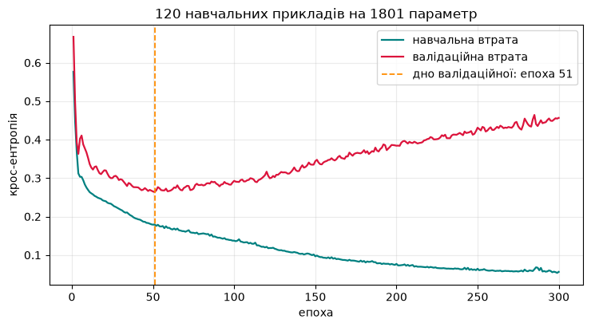

```
Криві розходяться після ~50-ї епохи: далі мережа вчить уже не закономірність,
а особисті риси конкретних 120 оголошень.
```

```python
fig, ax = plt.subplots(figsize=(7.5, 4.2))
ax.plot(range(1, 301), навч_база, color="teal", lw=1.6, label="навчальна втрата")
ax.plot(range(1, 301), вал_база, color="crimson", lw=1.6, label="валідаційна втрата")
ax.axvline(епоха_база, color="darkorange", ls="--", lw=1.3,
           label=f"дно валідаційної: епоха {епоха_база}")
ax.set_xlabel("епоха"); ax.set_ylabel("крос-ентропія")
ax.set_title("120 навчальних прикладів на 1801 параметр")
ax.grid(alpha=.25); ax.legend()
plt.tight_layout(); plt.show()

print("Криві розходяться після ~50-ї епохи: далі мережа вчить уже не закономірність,")
print("а особисті риси конкретних 120 оголошень.")
```

## 7 · Чи здатна вона вчити напамʼять? Перемішані мітки

Найпряміша перевірка того, що мережа не «шукає просте пояснення», а просто запамʼятовує. Перемішуємо мітки між прикладами: частки класів лишаються ті самі, а звʼязок між ознаками й відповіддю зникає повністю. Вивчити тут нема чого.

Даємо мережі більше часу — 2000 епох замість 300, бо запамʼятовувати важче, ніж вчитись.

```python
перестановка = np.random.default_rng(2024).permutation(len(y_навч))
мітки_випадкові = y_навч[перестановка]

print(f"частка шахрайських лишилась та сама: {мітки_випадкові.mean():.4f}")
print(f"збіглося з правдою випадково:        {(мітки_випадкові == y_навч).mean():.4f}")

ваги_шум, навч_шум, _, _, _ = навчити(епох=2000, мітки_навч=мітки_випадкові)

прогноз_шум = прямий_прохід(ваги_шум, X_навч) > 0.5
print(f"\nвтрата на перемішаних мітках:  {навч_шум[-1]:.4f}")
print(f"точність на цих же мітках:     {(прогноз_шум == (мітки_випадкові > 0.5)).mean():.4f}")
print(f"точність на тестовій вибірці:  {точність(ваги_шум, X_тест, y_тест):.4f}")
print(f"для порівняння, «усі чесні»:   {1 - y_тест.mean():.4f}")
print("\nМережа вивчила напамʼять таблицю, у якій немає жодної закономірності,")
print("і на нових даних стала гіршою за найтупішу сталу відповідь.")
```

```
частка шахрайських лишилась та сама: 0.1667
збіглося з правдою випадково:        0.7167
```

```
втрата на перемішаних мітках:  0.0128
точність на цих же мітках:     1.0000
точність на тестовій вибірці:  0.7141
для порівняння, «усі чесні»:   0.8372

Мережа вивчила напамʼять таблицю, у якій немає жодної закономірності,
і на нових даних стала гіршою за найтупішу сталу відповідь.
```